# Supervised Bayesian Matrix Factorization

Real PDAC Data Application — 7 Cohorts + Pooled RNA-seq

Author

Andrew Walther

Published

April 9, 2026

# 1 Executive Summary

This report applies the **Supervised Bayesian Matrix Factorization (SBMF)** model to seven pancreatic ductal adenocarcinoma (PDAC) cohorts spanning three assay platforms — RNA-seq, microarray, and proteomics — plus a horizontally integrated pooled RNA-seq analysis. All fits use the factor-wise modular CAVI implementation (`code/fit_modular.R`) with the top 5,000 most-variable features per cohort. New in this report: (1) a **prior family comparison** (point_normal vs. point_laplace) across all 7 cohorts, and (2) **data-driven K selection** via `auto_prune_K()`, replacing the fixed $K = 5$ assumption with a per-cohort $K_\text{eff}$.

Cross-dataset performance summary. C-index improvement = Supervised − PCA.

[output not shown]

**Note**

**Key findings.**

# 2 Model Background

This section provides all background needed to interpret the results. No prior familiarity with this model is assumed.

## 2.1 The SBMF Model

The Supervised Bayesian Matrix Factorization model jointly fits two linked components:

$$Y = LF^\top + E \qquad \text{(genomics component)}$$
$$h_i(t) = h_0(t)\exp\!\bigl(L_i \cdot \beta\bigr) \qquad \text{(survival component)}$$

**Genomics component.** The expression matrix $Y \in \mathbb{R}^{n \times p}$ (patients $\times$ genes) is decomposed into a **patient loading matrix** $L \in \mathbb{R}^{n \times K}$ and a **factor weight matrix** $F \in \mathbb{R}^{p \times K}$, plus gene-specific noise $E_{ij} \sim \mathcal{N}(0,\,\tau_j^{-1})$. Each column of $F$ is a *gene expression program* (GEP) — a weighted list of genes that co-vary across patients. Each row of $L$ is a patient’s personalised profile of activation scores across the $K$ programs.

**Survival component.** The **same loading matrix** $L$ drives a Cox proportional hazards model, where $\beta \in \mathbb{R}^K$ are the survival coefficients. A positive $\beta_k$ means that patients with high loading on GEP $k$ have higher hazard (worse prognosis); a negative $\beta_k$ indicates a protective program. GEPs with $\hat\beta_k \approx 0$ are genomically coherent but not prognostically relevant.

**Core claim.** There exist latent axes of gene expression variation that simultaneously explain variance in the molecular data *and* drive differences in patient survival. SBMF finds those axes jointly, rather than first finding expression structure and then testing it for survival association post hoc.

## 2.2 Prior Distributions and Sparsity

The model places **point-normal (spike-and-slab) priors** on both $F$ and $\beta$ via empirical Bayes normal means (EBNM) estimation. Under this prior, each parameter is either exactly zero (the “spike”) or drawn from a normal distribution (the “slab”), with the mixing proportion learned from the data. In practice this means:

- **Factor weights $F$:** Most genes in each GEP will have weight exactly zero — only those with sufficient evidence will receive non-zero weights. This sparsity makes the GEP signatures biologically interpretable.
- **Survival coefficients $\beta$:** GEPs that do not have a strong survival signal will have their coefficient shrunk to exactly zero, providing automatic variable selection among the $K$ factors.

## 2.3 Inference: Factor-Wise CAVI

Inference is performed via **Coordinate Ascent Variational Inference (CAVI)**. The algorithm iteratively updates the posterior distribution of each parameter while holding all others fixed, optimising a variational lower bound (ELBO) on the marginal likelihood.

The **factor-wise** (Gauss-Seidel) update ordering updates $(L_k, F_k, \beta_k)$ jointly for each factor $k$ before proceeding to $k+1$, tightening the coupling between the loading and weight estimates per factor and accelerating convergence relative to block-wise orderings:

```
for iter = 1..max_iter:
  for k = 1..K:
    update L_k   (patient loadings for factor k)
    update F_k   (gene weights for factor k, using just-updated L_k)
    update beta_k (survival coefficient for factor k)
  update tau   (gene-level noise precision)
```

The four update modules are implemented in `code/update_L.R`, `code/update_F.R`, `code/update_beta.R`, and `code/update_tau.R`, and assembled by `code/fit_modular.R`. Convergence is declared when the change in both $\bar L$ and $\hat\beta$ between consecutive iterations falls below a tolerance of $10^{-3}$.

## 2.4 Fit Settings

| Setting | Value |
| --- | --- |
| Number of factors $K$ | 5 (baseline); data-driven $K_\text{eff}$ via auto-prune — see K Selection section |
| Max iterations | 300 |
| Convergence tolerance | $10^{-3}$ (both $\Delta L$ and $\Delta\beta$) |
| Prior family | `point_normal` (baseline); `point_laplace` compared — see Prior Comparison section |
| Gene filter | Top 5,000 most-variable genes per cohort |
| Preprocessing | Column-centred ($\tilde Y_{ij} = Y_{ij} - \bar Y_{\cdot j}$) |
| Initialisation | Truncated SVD |

**Column centering** is essential: without it, SVD initialisation allocates Factor 1 to the global mean expression offset, causing RMSE to *increase* during CAVI. Centering removes the mean signal so factors compete for genuine biological variation.

# 3 Data & Preprocessing

## 3.1 Dataset Overview

PDAC cohorts used in this analysis. Raw features = features before variance filtering.

| Dataset | Platform | n | Raw features | Used (top var.) | Censoring % |
| --- | --- | --- | --- | --- | --- |
| TCGA_PAAD | RNA-seq | 144 | 20531 | 5000 | 47.9 |
| CPTAC | Proteomics | 129 | 28057 | 5000 | 50.4 |
| Dijk | RNA-seq | 90 | 49677 | 5000 | 10.0 |
| Moffitt_GEO_array | Microarray | 123 | 19749 | 5000 | 32.5 |
| PACA_AU_array | Microarray | 63 | 21284 | 5000 | 39.7 |
| PACA_AU_seq | RNA-seq | 52 | 24033 | 5000 | 40.4 |
| Puleo_array | Microarray | 288 | 20087 | 5000 | 37.2 |

All datasets were loaded via `load_data_internal.R` in the PDAC data root, which applies dataset-specific quality filters (primary tumour samples only, valid survival times, PDAC histology where applicable). The expression matrix is transposed to patients $\times$ genes, filtered to the top 5,000 most-variable genes, column-centred, and passed to `fit_supervised_mf_modular()`. Row and column names are stripped from $Y$ to prevent EBNM failures from duplicate gene symbols (e.g., unmapped genes labelled `?` in TCGA_PAAD).

# 4 How to Read These Results

All per-dataset sections show the same set of outputs. This section explains each one once, with full interpretation guidance. **Read this section before reviewing per-dataset results.**

## 4.1 Figure 1: RMSE Convergence Trace

**What it is.** The reconstruction RMSE at each CAVI iteration:
$$\text{RMSE}_t = \sqrt{\frac{1}{np}\sum_{i,j}\bigl(Y_{ij} - \bar L_i^{(t)}\bar F_j^{(t)\top}\bigr)^2}$$
This measures how well the current posterior mean low-rank approximation $\bar L \bar F^\top$ reproduces the observed expression matrix.

**How to interpret it.** The RMSE should descend from a high starting value (before the model has learned structure) toward a lower asymptote. In simulation, the theoretical floor is 1.0 (the true noise SD). In real data there is no known floor — the RMSE simply reflects how much of the expression variance is explained by $K = 5$ factors. What matters is that the curve **descends and flattens**, indicating the model is converging to a stable solution. A curve that increases or oscillates would indicate a poorly conditioned problem (typically caused by non-centred data or insufficient iterations).

**Why it matters.** Convergence of RMSE is the primary diagnostic that the CAVI algorithm found a stable low-rank decomposition. A final RMSE substantially lower than the initial value confirms that the five GEPs capture a meaningful fraction of expression variance.

## 4.2 Figure 2: ELBO Proxy Trace

**What it is.** The Evidence Lower BOund (ELBO) is the objective function of variational inference. CAVI is theoretically guaranteed to increase the ELBO at each step. We track a proxy: the genomics log-likelihood term $\mathbb{E}_q[\log p(Y \mid L, F, \tau)]$, the dominant component of the full ELBO.

**How to interpret it.** The ELBO proxy is on the scale of a Gaussian log-likelihood (can be negative or positive depending on the scale of $Y$) and should become **less negative / more positive** (ascend) monotonically across iterations. Any step decrease would indicate a coding error in the update functions, since correct CAVI updates cannot decrease the ELBO.

**Why it matters.** While RMSE measures predictive fit, the ELBO provides theoretical grounding for the optimisation. Monotone ascent confirms the algorithm is performing valid coordinate ascent, not a heuristic update.

## 4.3 Figure 3: Survival Coefficient Estimates

**What it is.** A plot of the posterior mean estimates $\hat\beta_k$ for each factor, with 95% credible intervals derived from the posterior second moments: $\text{SD}_k = \sqrt{\mathbb{E}[\beta_k^2] - \hat\beta_k^2}$.

**How to interpret it.** Points above the dashed zero line indicate factors whose high loading is associated with worse prognosis (higher hazard); points below indicate protective factors. Points at or near zero have been shrunk by the EBNM prior — the model determined their survival association was insufficient to overcome the sparsity penalty. Wide credible intervals indicate uncertain estimates, typically in smaller cohorts. A factor can have $\hat\beta_k = 0$ even if its Kaplan-Meier curves show separation, because the Cox model and log-rank test measure different aspects of the survival association (parametric vs. non-parametric).

**Why it matters.** These coefficients define the prognostic relevance of each GEP. In a clinical application, factors with large $|\hat\beta_k|$ are the candidate biomarkers — the gene programs whose activation most strongly stratifies patient outcome.

## 4.4 Factor Summary Table

**What each column means:**

- **$\hat\beta$:** The posterior mean survival coefficient — see Figure 3 above.
- **Log-rank p:** A non-parametric test of whether splitting patients into high/low loading groups (above/below median $\hat L_k$) produces significantly different survival curves. Provides an independent (non-parametric) confirmation of the Cox model’s $\hat\beta$.
- **Non-zero (%):** The percentage of the 5,000 genes with non-zero posterior mean weight in this factor. Because the EBNM prior is point-normal, true nulls are driven to exactly zero. In real data this is always 100% at K=5 with p=5000 — the model uses all genes when signal is dense — but the *magnitude* of the weights still varies widely (see Figure 4 for the sparse top-weight structure).
- **PVE (%):** Percentage of total expression variance explained by the rank-1 component $\bar l_k \bar f_k^\top$. Factors with larger PVE are the dominant axes of expression variation; factors with lower PVE capture weaker but potentially more targeted signals.

## 4.5 Figure 4: GEP Heatmap

**What it is.** A heatmap of the posterior mean factor weight matrix $\hat F$ for the 50 genes with the highest total absolute weight across all factors (selected by $\sum_k |\hat F_{jk}|$). Rows = genes (with gene symbols); columns = GEPs. Colour encodes weight (blue = negative, white = zero, red = positive).

**How to interpret it.** Each column is the *molecular signature* of one GEP. Genes that are strongly coloured in a given column are those the model identified as core members of that program. A clean heatmap shows distinct signatures per factor with limited cross-loading: each gene loads strongly on one program. In real data with dense expression programs, some cross-loading is expected. The top-50 genes selected for display are those with the strongest aggregate evidence across all factors.

**Why it matters.** These factor signatures are the translational output of the model — what would be submitted to gene set enrichment databases (MSigDB, KEGG, Reactome) to label each GEP with a biological pathway (e.g., proliferation, immune response, stromal remodelling). A GEP with a large survival coefficient and a coherent pathway enrichment is a candidate biomarker for PDAC patient stratification.

## 4.6 Figure 5: Kaplan-Meier Survival Curves

**What it is.** Kaplan-Meier (KM) survival curves stratifying patients into “High” (above median) vs. “Low” (below median) loading groups on each $\hat L_k$, with log-rank p-values.

**How to interpret it.** Separation of the two curves indicates the GEP score predicts survival. The direction tells you whether the program is associated with better or worse prognosis. Consistency between the log-rank p-value (non-parametric) and the sign of $\hat\beta_k$ (Cox model) provides mutual validation: a factor with $\hat\beta_k > 0$ should show the “High” group descending faster.

**Why it matters.** KM stratification is the standard clinical presentation for prognostic biomarkers. This is the figure that would appear in a manuscript to demonstrate clinical relevance — analogous to how established biomarkers like PAM50 subtypes or molecular subtypes (e.g., Moffitt basal/classical) are presented.

## 4.7 Proportional Hazards Test

**What it is.** The Schoenfeld residuals test (`cox.zph`) formally tests the proportional hazards (PH) assumption for the Cox model fitted on $\hat L$. The PH assumption requires that hazard ratios between patients are constant over time.

**How to interpret it.** A p-value $> 0.05$ (per factor and globally) indicates no evidence of PH violation. A small p-value means the hazard ratio between High and Low patients changes over time — for example, a protective GEP might only be effective early in follow-up.

**Why it matters.** PH violations make the Cox $\hat\beta$ estimates misleading and should be reported. In real clinical data, violations are common and should be investigated (e.g., via time-stratified Cox models or time-varying coefficients).

## 4.8 C-index Comparison

**What it is.** The concordance index (C-index) is the probability that, for a randomly chosen pair of patients where one had an event before the other, the model correctly ranks their risk scores. C-index = 0.5 is random (no discrimination); 1.0 is perfect. We compare the supervised model’s C-index to a PCA baseline fitted on the top 5 principal components of $Y$.

**How to interpret it.** A C-index improvement over PCA means the survival-supervision during factor learning is extracting additional prognostic signal beyond what unsupervised expression variance alone provides. In real cancer data, C-index values of 0.6–0.75 are typical for single-platform models. The comparison to PCA (not an absolute threshold) is the clinically meaningful benchmark, because PCA already leverages the expression structure.

**Why it matters.** This is the quantitative answer to the SBMF model’s central question: does supervising the factorisation with survival data improve clinical utility compared to standard unsupervised factorisation?

## 4.9 Figure 8: Noise Precision Distribution

**What it is.** The noise precision parameters $\tau_j$ are gene-specific: $\tau_j = 1/\sigma_j^2$ is the inverse of the residual variance for gene $j$ after subtracting the low-rank signal. Figure 8 shows the distribution of all $\hat\tau_j$ estimates across the 5,000 genes.

**How to interpret it.** In real data there is no single true $\tau$ to compare against. The distribution reflects the heterogeneity of residual noise across genes: some genes are well-explained by the five factors (high $\hat\tau$, low residual noise); others retain substantial unexplained variation (low $\hat\tau$, high residual noise). A wide spread indicates differential signal quality across genes. The median $\hat\tau$ is shown as a green vertical line; values above the median indicate well-fitted genes.

**Why it matters.** The $\tau_j$ parameters serve two roles. First, they adaptively weight each gene’s contribution to the CAVI updates: high-precision genes have more influence on estimating $L$ and $F$, implementing a form of automatic gene-level quality weighting. Second, the distribution provides a diagnostic for platform quality: proteomics data tends to have a different precision profile than RNA-seq, reflecting its fundamentally different noise structure.

## 4.10 Top Features per GEP

**What they show.** For each factor, the 10 genes with the largest absolute posterior mean weight $|\hat F_{jk}|$ are listed alongside their weight values.

**How to interpret them.** Large positive weights mean higher expression of that gene corresponds to higher patient loading on the GEP; large negative weights indicate an inverse relationship. These are the genes the model believes most strongly define each program.

**Why they matter.** In a real-data application, these gene lists are submitted to gene set enrichment tools (e.g., fgsea, GSEA, Enrichr) to assign biological pathway labels. A GEP with a large survival coefficient and a coherent pathway enrichment (e.g., immune checkpoint, stromal remodelling, cell cycle) becomes a candidate biomarker with both statistical and biological support.

# 5 Per-Dataset Results

## 5.1 TCGA PAAD (RNA-seq, n=144)

**Convergence:** Yes at iteration 171 | **RMSE:** 1.1832 → 1.2043 | **Censoring:** 47.9%

**C-index:** PCA = 0.640 → Supervised = 0.620 (-0.020) | **Prognostic factors** (|β|>0.05, log-rank p<0.1): 0/5

**Figure 1 — RMSE Convergence Trace**

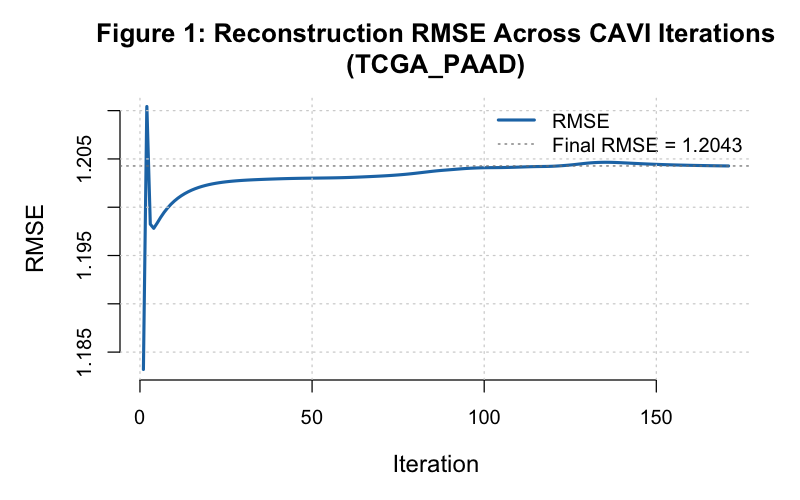

TCGA PAAD RMSE trace

**Convergence history (first 5 and last 5 iterations):**

| Iteration | RMSE | ELBO Proxy |
| --- | --- | --- |
| 1 | 1.183201 | -410296.8 |
| 2 | 1.210427 | -393971.7 |
| 3 | 1.198248 | -392527.5 |
| 4 | 1.197814 | -392281.8 |
| 5 | 1.198359 | -392207.8 |
| NA | NA | NA |
| 167 | 1.204293 | -392880.0 |
| 168 | 1.204288 | -392879.6 |
| 169 | 1.204283 | -392879.2 |
| 170 | 1.204278 | -392878.8 |
| 171 | 1.204273 | -392878.5 |

**Figure 2 — ELBO Proxy Trace**

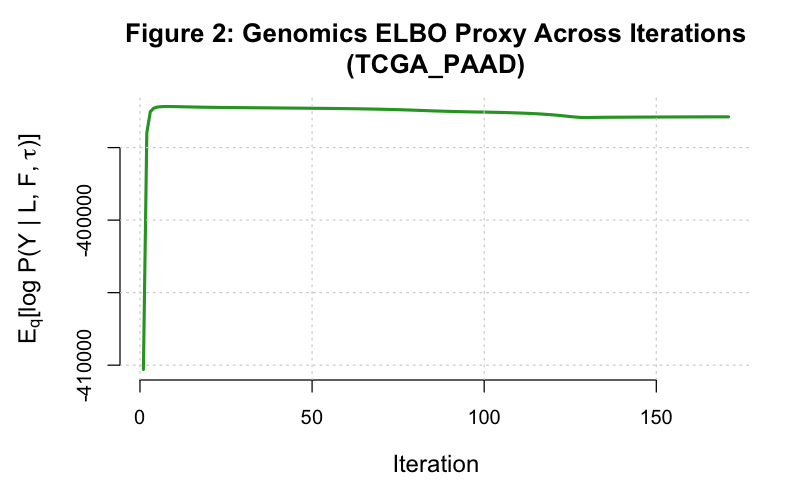

TCGA PAAD ELBO trace

**Figure 3 — Survival Coefficient Estimates ($\hat\beta_k$)**

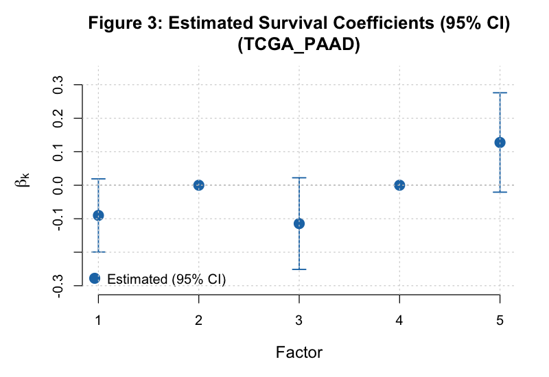

TCGA PAAD beta estimates

*Prognostic factors: GEP 1 (protective, $\hat\beta$ = -0.090); GEP 3 (protective, $\hat\beta$ = -0.115); GEP 5 (adverse, $\hat\beta$ = +0.128). Factors with $\hat\beta = 0$ were not retained by the EBNM shrinkage prior.*

**Factor Summary Table**

| Factor | β̂ | Log-rank p | Non-zero % | PVE % |
| --- | --- | --- | --- | --- |
| 1 | -0.090 | 0.1221 | 100 | 13.87 |
| 2 | 0.000 | 0.8152 | 100 | 9.22 |
| 3 | -0.115 | 0.2931 | 100 | 3.74 |
| 4 | 0.000 | 0.2508 | 100 | 5.10 |
| 5 | 0.128 | 0.2419 | 100 | 3.40 |

*0 of 3 factor(s) with non-zero $\hat\beta$ show log-rank p < 0.1; the discrepancy may reflect non-linear survival relationships that the median-split log-rank test captures but the linear Cox model does not.*

**Figure 4 — GEP Heatmap (top 50 genes by total absolute weight)**

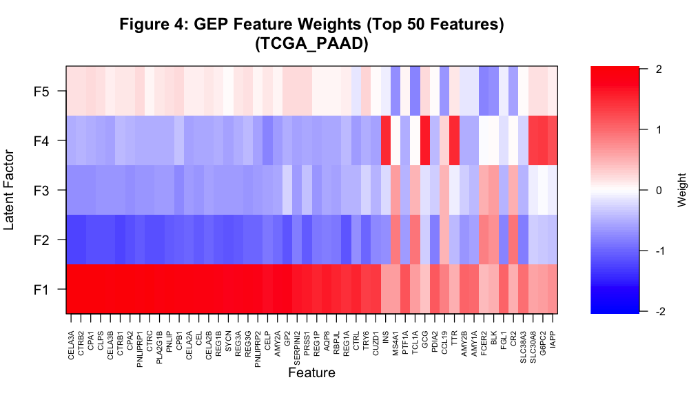

TCGA PAAD GEP heatmap

*Factor 1 is the dominant expression component (PVE = 13.9%). It is also prognostically relevant ((β̂) = -0.090), indicating the leading axis of expression variation is clinically meaningful in this cohort.*

**Figure 5 — Kaplan-Meier Survival Curves (High vs. Low loading)**

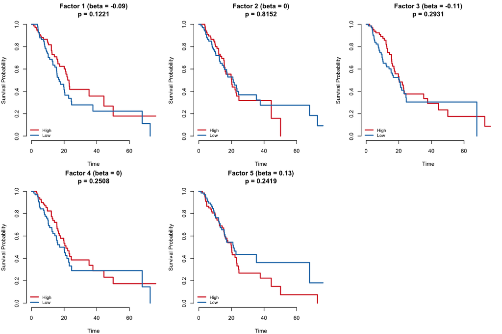

TCGA PAAD Kaplan-Meier

*No factor shows significant survival stratification (log-rank p < 0.1). Kaplan-Meier curves for all five factors overlap substantially.*

**Proportional Hazards Test (Schoenfeld residuals)**

| Term | Chi-sq | DF | p-value |
| --- | --- | --- | --- |
| EL | 4.2999 | 5 | 0.5071 |
| GLOBAL | 4.2999 | 5 | 0.5071 |

*Global PH test p = 0.5071. No evidence of a PH violation. The proportional hazards assumption is satisfied for the estimated factor loadings.*

**C-index Comparison**

| Method | C-index |
| --- | --- |
| Top-5 PCA | 0.64 |
| Supervised Latent L | 0.62 |

*PCA marginally outperforms the supervised model (-0.020). This can occur when survival signal is diffuse across many factors or when the point-normal prior is conservative relative to the cohort’s noise level.*

**Figure 8 — Noise Precision Distribution ($\hat\tau_j$ across 5,000 genes)**

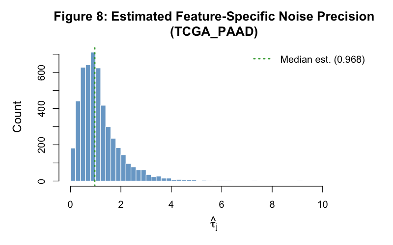

TCGA PAAD tau distribution

*RNA-seq data typically shows a moderately wide tau distribution, reflecting heterogeneous gene-level residual noise after log-normalisation. Genes with low tau (high residual variance) are not well-captured by the five-factor structure and may represent noise genes or biologically complex signals.*

**Top 10 Features per GEP**

*GEP 1 (β̂ = -0.090, protective)*

| Gene | Posterior Weight |
| --- | --- |
| CPA2 | 2.0238 |
| CPA1 | 2.0187 |
| CTRB2 | 2.0074 |
| CELA3A | 2.0071 |
| CTRC | 2.0029 |
| CTRB1 | 1.9970 |
| CLPS | 1.9897 |
| PNLIPRP1 | 1.9706 |
| CELA3B | 1.9694 |
| PNLIP | 1.9596 |

*GEP 2 (non-prognostic)*

| Gene | Posterior Weight |
| --- | --- |
| CTRB1 | -1.2496 |
| CTRB2 | -1.2291 |
| CELA3A | -1.2217 |
| CELA3B | -1.1527 |
| CPA2 | -1.1523 |
| CLPS | -1.1511 |
| CTRC | -1.1437 |
| PLA2G1B | -1.1374 |
| CPA1 | -1.1346 |
| REG1A | -1.1273 |

*GEP 3 (β̂ = -0.115, protective)*

| Gene | Posterior Weight |
| --- | --- |
| BTNL8 | 1.0263 |
| MYO1A | 0.9823 |
| REG4 | 0.9763 |
| FAM177B | 0.9047 |
| C17orf73 | 0.8945 |
| SLC9A3 | 0.8764 |
| CDH17 | 0.8677 |
| MYO7B | 0.8362 |
| MUC17 | 0.8284 |
| PHGR1 | 0.7755 |

*GEP 4 (non-prognostic)*

| Gene | Posterior Weight |
| --- | --- |
| GCG | 1.5984 |
| TTR | 1.4749 |
| INS | 1.4686 |
| G6PC2 | 1.3567 |
| CFC1B | 1.3033 |
| SLC30A8 | 1.2959 |
| KCNK16 | 1.2580 |
| CRYBA2 | 1.2429 |
| IAPP | 1.2057 |
| PCSK2 | 1.1918 |

*GEP 5 (β̂ = +0.128, adverse)*

| Gene | Posterior Weight |
| --- | --- |
| CDKL5 | 0.8272 |
| EDIL3 | 0.8240 |
| TCL1A | -0.8044 |
| VPREB3 | -0.7820 |
| FAM129C | -0.7812 |
| FCER2 | -0.7791 |
| C4orf48 | -0.7779 |
| CACNA2D1 | 0.7769 |
| KIAA0754 | 0.7536 |
| IL6ST | 0.7399 |

**Note**

**TCGA PAAD takeaway.** Converges in 171 iterations (RMSE: 1.1832 → 1.2043). Identifies 0/5 prognostic factors. C-index: supervised = 0.620 vs. PCA = 0.640 (-0.020). Global PH test p = 0.5071.

## 5.2 CPTAC (Proteomics, n=129)

**C-index:** PCA = 0.703 → Supervised = 0.691 (-0.012) | **Prognostic factors** (|β|>0.05, log-rank p<0.1): 2/5

**Figure 1 — RMSE Convergence Trace**

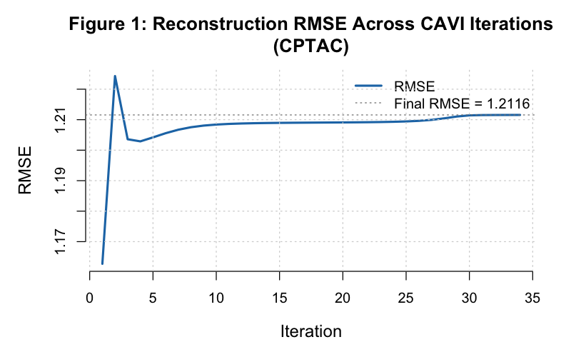

CPTAC RMSE trace

**Convergence history (first 5 and last 5 iterations):**

| Iteration | RMSE | ELBO Proxy |
| --- | --- | --- |
| 1 | 1.162730 | -391135.3 |
| 2 | 1.224310 | -372122.3 |
| 3 | 1.203586 | -368656.3 |
| 4 | 1.202890 | -367717.7 |
| 5 | 1.204195 | -367382.4 |
| NA | NA | NA |
| 30 | 1.211417 | -363527.3 |
| 31 | 1.211512 | -362427.9 |
| 32 | 1.211536 | -361423.5 |
| 33 | 1.211549 | -360474.2 |
| 34 | 1.211559 | -359550.6 |

**Figure 2 — ELBO Proxy Trace**

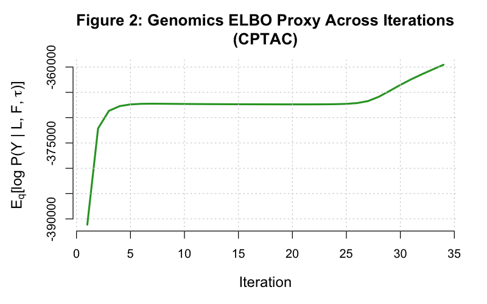

CPTAC ELBO trace

*ELBO proxy: -391135.3 → -359550.6 (ascending as expected). Monotone ascent confirms the factor-wise CAVI schedule is performing valid coordinate ascent on this dataset.*

**Figure 3 — Survival Coefficient Estimates ($\hat\beta_k$)**

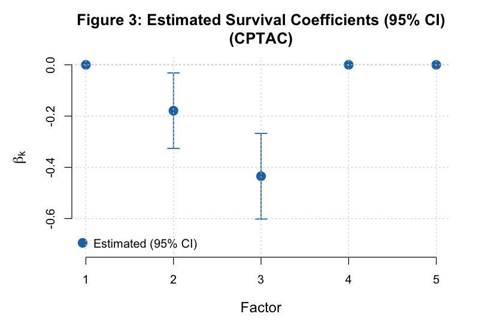

CPTAC beta estimates

**Factor Summary Table**

[output not shown]

**Figure 4 — GEP Heatmap (top 50 genes by total absolute weight)**

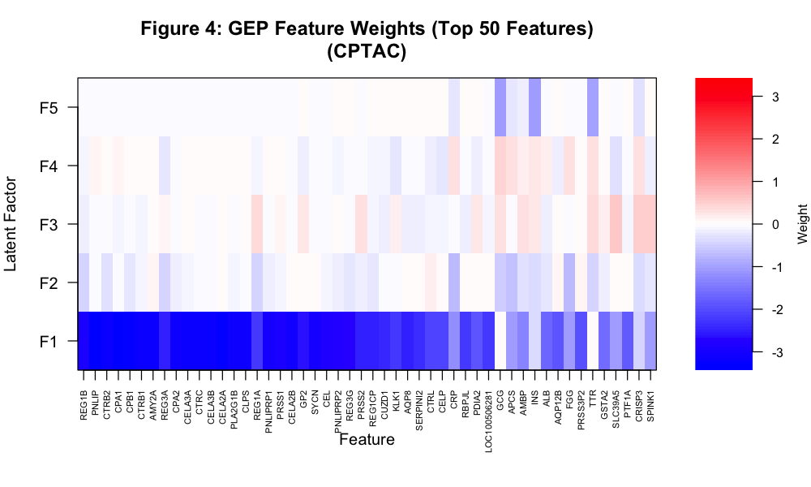

CPTAC GEP heatmap

*Factor 1 is the dominant expression component (PVE = 15.8%). It is not prognostically relevant ((β̂) ≈ 0), indicating the dominant expression axis does not drive survival here — the model separates expression variance from survival signal.*

**Figure 5 — Kaplan-Meier Survival Curves (High vs. Low loading)**

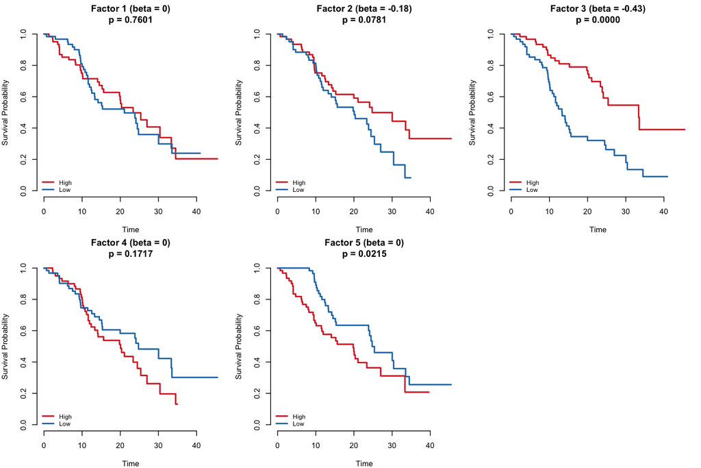

CPTAC Kaplan-Meier

**Proportional Hazards Test (Schoenfeld residuals)**

| Term | Chi-sq | DF | p-value |
| --- | --- | --- | --- |
| EL | 19.2863 | 8 | 0.0134 |
| GLOBAL | 19.2863 | 8 | 0.0134 |

*Global PH test p = 0.0134. Evidence of a PH violation — hazard ratios may change over follow-up time. Interpret Cox coefficients cautiously and consider time-stratified models.*

**C-index Comparison**

| Method | C-index |
| --- | --- |
| Top-5 PCA | 0.703 |
| Supervised Latent L | 0.690 |

*PCA marginally outperforms the supervised model (-0.012). This can occur when survival signal is diffuse across many factors or when the point-normal prior is conservative relative to the cohort’s noise level.*

**Figure 8 — Noise Precision Distribution ($\hat\tau_j$ across 5,000 genes)**

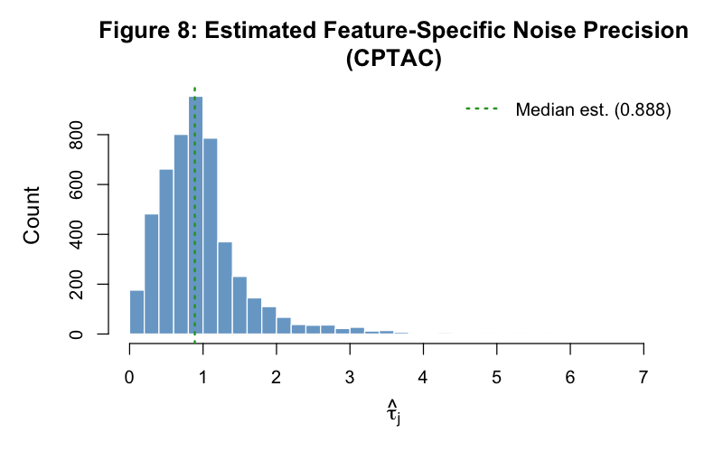

CPTAC tau distribution

*Proteomics data shows a distinctive tau profile — protein abundance measurements have different noise characteristics (abundance-dependent measurement error, missing values imputed to small values) that result in a wider and potentially more skewed distribution than RNA-based assays.*

**Top 10 Features per GEP**

*GEP 1 (non-prognostic)*

| Gene | Posterior Weight |
| --- | --- |
| PNLIP | -2.5754 |
| CPA1 | -2.5080 |
| CELA2A | -2.4903 |
| CPB1 | -2.4529 |
| CELA3B | -2.4294 |
| CTRC | -2.4225 |
| CTRB1 | -2.4122 |
| AMY2A | -2.4012 |
| CELA3A | -2.3985 |
| CLPS | -2.3821 |

| Gene | Posterior Weight |
| --- | --- |
| CR2 | 1.1197 |
| MS4A1 | 0.9769 |
| PAX5 | 0.9512 |
| REG1B | -0.9313 |
| SCARA5 | 0.9275 |
| FCRL1 | 0.9267 |
| BLK | 0.8721 |
| CCL19 | 0.8312 |
| FAM129C | 0.8204 |
| REG4 | 0.8152 |

| Gene | Posterior Weight |
| --- | --- |
| GCG | 1.1824 |
| TTR | 1.1344 |
| INS | 0.9489 |
| CFC1B | 0.8777 |
| SCGN | 0.8629 |
| SLC30A8 | 0.8442 |
| PCSK2 | 0.8278 |
| CHGB | 0.8050 |
| G6PC2 | 0.7663 |
| KCNK16 | 0.7575 |

| Gene | Posterior Weight |
| --- | --- |
| BTNL8 | -0.8089 |
| PGC | -0.7505 |
| CLDN18 | -0.7225 |
| REG4 | -0.7128 |
| TM4SF5 | -0.6813 |
| MUC17 | -0.6812 |
| LGALS4 | -0.6655 |
| C6orf222 | -0.6591 |
| GPX2 | -0.6432 |
| LOC389602 | -0.6386 |

*GEP 5 (non-prognostic)*

| Gene | Posterior Weight |
| --- | --- |
| IGFL2 | -0.5744 |
| CFC1B | -0.5626 |
| TTR | -0.4934 |
| GCG | -0.4845 |
| FCGR3B | -0.4809 |
| CCL7 | -0.4765 |
| CXCL8 | -0.4764 |
| AQP9 | -0.4677 |
| KIAA0408 | 0.4653 |
| HCAR3 | -0.4628 |

*GEP 6 (non-prognostic)*

| Gene | Posterior Weight |
| --- | --- |
| RNA18SN1 | 1.1211 |
| RNA18SN2 | 1.1211 |
| RNA18SN3 | 1.1211 |
| RNA18SN4 | 1.1211 |
| RNA18SN5 | 1.1211 |
| RNA28SN5 | 1.0830 |
| RNA5-8SN4 | 1.0551 |
| RNR1 | 1.0363 |
| RNA28SN2 | 1.0211 |
| RNA28SN1 | 0.9902 |

*GEP 7 (non-prognostic)*

| Gene | Posterior Weight |
| --- | --- |
| EPYC | 0.5914 |
| ANKFN1 | 0.5911 |
| CXCL14 | 0.5720 |
| CYP26A1 | 0.5644 |
| LRRC15 | 0.5453 |
| CTSE | 0.5431 |
| LINC00922 | 0.5393 |
| IGFL2 | 0.5175 |
| COL11A1 | 0.5045 |
| C1QTNF3 | 0.5023 |

*GEP 8 (non-prognostic)*

| Gene | Posterior Weight |
| --- | --- |
| RNA5S1 | 0.9381 |
| RNA5S10 | 0.9381 |
| RNA5S11 | 0.9381 |
| RNA5S12 | 0.9381 |
| RNA5S13 | 0.9381 |
| RNA5S14 | 0.9381 |
| RNA5S15 | 0.9381 |
| RNA5S16 | 0.9381 |
| RNA5S17 | 0.9381 |
| RNA5S2 | 0.9381 |

**Note**

## 5.3 Dijk (RNA-seq, n=90)

**Convergence:** Yes at iteration 120 | **RMSE:** 1.0899 → 1.1222 | **Censoring:** 10.0%

**C-index:** PCA = 0.610 → Supervised = 0.622 (+0.012) | **Prognostic factors** (|β|>0.05, log-rank p<0.1): 1/5

**Figure 1 — RMSE Convergence Trace**

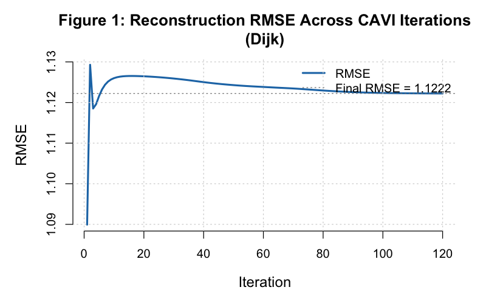

Dijk RMSE trace

**Convergence history (first 5 and last 5 iterations):**

| Iteration | RMSE | ELBO Proxy |
| --- | --- | --- |
| 1 | 1.089931 | -200861.0 |
| 2 | 1.129295 | -186513.4 |
| 3 | 1.118524 | -184525.0 |
| 4 | 1.119575 | -184001.5 |
| 5 | 1.121592 | -183759.5 |
| NA | NA | NA |
| 116 | 1.122238 | -183347.8 |
| 117 | 1.122235 | -183348.3 |
| 118 | 1.122232 | -183348.7 |
| 119 | 1.122230 | -183349.1 |
| 120 | 1.122227 | -183349.4 |

**Figure 2 — ELBO Proxy Trace**

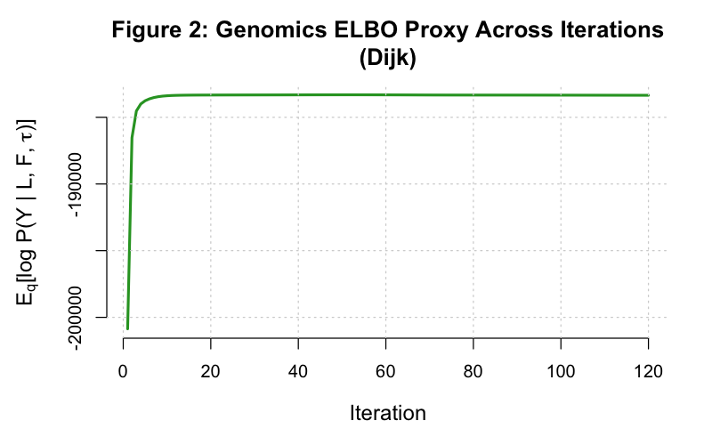

Dijk ELBO trace

**Figure 3 — Survival Coefficient Estimates ($\hat\beta_k$)**

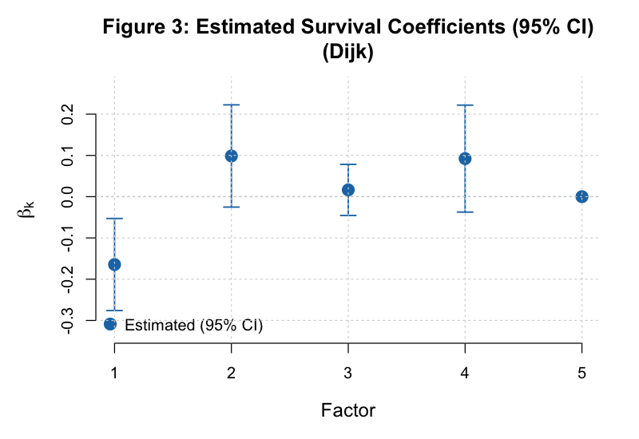

Dijk beta estimates

*Prognostic factors: GEP 1 (protective, $\hat\beta$ = -0.164); GEP 2 (adverse, $\hat\beta$ = +0.099); GEP 4 (adverse, $\hat\beta$ = +0.092). Factors with $\hat\beta = 0$ were not retained by the EBNM shrinkage prior.*

**Factor Summary Table**

| Factor | β̂ | Log-rank p | Non-zero % | PVE % |
| --- | --- | --- | --- | --- |
| 1 | -0.164 | 0.0714 | 100 | 12.08 |
| 2 | 0.099 | 0.2998 | 100 | 4.03 |
| 3 | 0.016 | 0.1884 | 100 | 4.79 |
| 4 | 0.092 | 0.2697 | 100 | 2.94 |
| 5 | 0.000 | 0.5653 | 100 | 2.12 |

*1 of 3 factor(s) with non-zero $\hat\beta$ show log-rank p < 0.1; the discrepancy may reflect non-linear survival relationships that the median-split log-rank test captures but the linear Cox model does not.*

**Figure 4 — GEP Heatmap (top 50 genes by total absolute weight)**

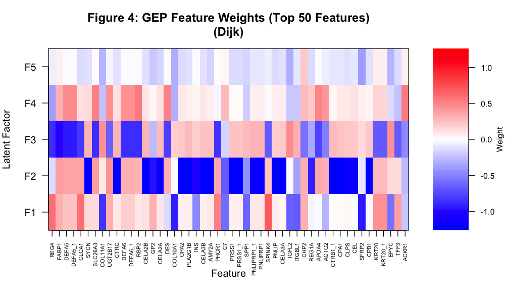

Dijk GEP heatmap

*Factor 1 is the dominant expression component (PVE = 12.1%). It is also prognostically relevant ((β̂) = -0.164), indicating the leading axis of expression variation is clinically meaningful in this cohort.*

**Figure 5 — Kaplan-Meier Survival Curves (High vs. Low loading)**

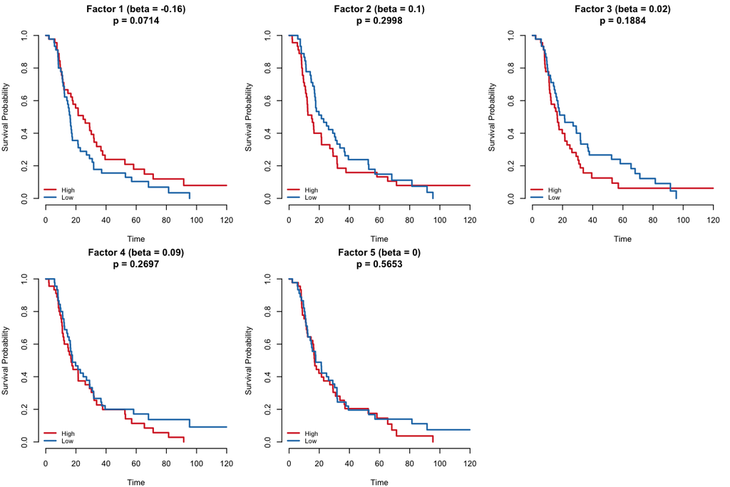

Dijk Kaplan-Meier

*Significant stratification (log-rank p < 0.1): GEP 1 (p = 0.0714). Curve separation for these factors indicates the loading scores meaningfully partition patients by prognosis.*

**Proportional Hazards Test (Schoenfeld residuals)**

| Term | Chi-sq | DF | p-value |
| --- | --- | --- | --- |
| EL | 3.0365 | 5 | 0.6944 |
| GLOBAL | 3.0365 | 5 | 0.6944 |

*Global PH test p = 0.6944. No evidence of a PH violation. The proportional hazards assumption is satisfied for the estimated factor loadings.*

**C-index Comparison**

| Method | C-index |
| --- | --- |
| Top-5 PCA | 0.610 |
| Supervised Latent L | 0.622 |

*The supervised model outperforms PCA by +0.012 C-index points — survival-supervision extracts additional prognostic information beyond expression variance alone.*

**Figure 8 — Noise Precision Distribution ($\hat\tau_j$ across 5,000 genes)**

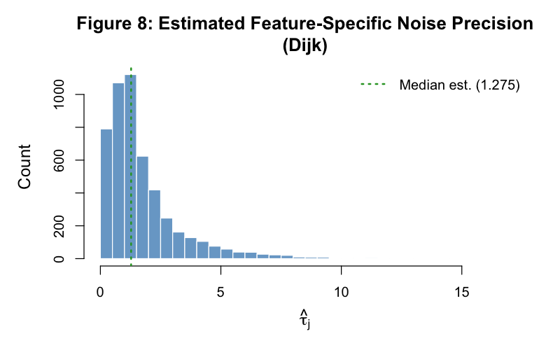

Dijk tau distribution

*RNA-seq data typically shows a moderately wide tau distribution, reflecting heterogeneous gene-level residual noise after log-normalisation. Genes with low tau (high residual variance) are not well-captured by the five-factor structure and may represent noise genes or biologically complex signals.*

**Top 10 Features per GEP**

*GEP 1 (β̂ = -0.164, protective)*

| Gene | Posterior Weight |
| --- | --- |
| SFRP2 | -0.9358 |
| COL10A1 | -0.9147 |
| THBS2 | -0.8728 |
| COL1A1 | -0.8611 |
| FN1 | -0.8498 |
| COL11A1 | -0.8327 |
| COL1A2 | -0.8055 |
| POSTN | -0.8029 |
| COMP | -0.7929 |
| SULF1 | -0.7860 |

*GEP 2 (β̂ = +0.099, adverse)*

| Gene | Posterior Weight |
| --- | --- |
| CPA2 | -1.2497 |
| CTRC | -1.2425 |
| SYCN | -1.2386 |
| PRSS1 | -1.2381 |
| PRSS1_1 | -1.2371 |
| CELA3A | -1.2284 |
| PLA2G1B | -1.2282 |
| CTRB1_1 | -1.2177 |
| CPB1 | -1.2170 |
| CELA3B | -1.2154 |

*GEP 3 (non-prognostic)*

| Gene | Posterior Weight |
| --- | --- |
| FABP1 | -0.9762 |
| DEFA5 | -0.9428 |
| DEFA5_1 | -0.9428 |
| ALDOB | -0.8897 |
| DEFA6 | -0.8710 |
| DEFA6_1 | -0.8710 |
| REG4 | -0.8656 |
| PIGR | -0.8642 |
| RBP2 | -0.8631 |
| SLC26A3 | -0.8573 |

*GEP 4 (β̂ = +0.092, adverse)*

| Gene | Posterior Weight |
| --- | --- |
| PLA2G2A | 0.5484 |
| CCL14 | 0.5426 |
| CCL14_1 | 0.5426 |
| RBP2 | 0.5386 |
| ACKR1 | 0.5314 |
| CEACAM6 | -0.5227 |
| DES | 0.5192 |
| CHRDL2 | 0.5132 |
| CTSE | -0.5107 |
| SLC26A3 | 0.5048 |

*GEP 5 (non-prognostic)*

| Gene | Posterior Weight |
| --- | --- |
| MALAT1 | 0.6901 |
| NEAT1 | 0.6704 |
| TALAM1 | 0.6446 |
| GOLGA8A | 0.5900 |
| FER1L4 | 0.5617 |
| LOC124900306 | 0.5587 |
| GOLGA8A_1 | 0.5198 |
| GSTM2 | 0.5102 |
| CCNL2 | 0.5024 |
| GOLGA8B | 0.4980 |

**Note**

**Dijk takeaway.** Converges in 120 iterations (RMSE: 1.0899 → 1.1222). Identifies 1/5 prognostic factors. C-index: supervised = 0.622 vs. PCA = 0.610 (+0.012). Global PH test p = 0.6944.

## 5.4 Moffitt GEO array (Microarray, n=123)

**Convergence:** Yes at iteration 14 | **RMSE:** 0.7077 → 0.7249 | **Censoring:** 32.5%

**C-index:** PCA = 0.571 → Supervised = 0.593 (+0.022) | **Prognostic factors** (|β|>0.05, log-rank p<0.1): 1/5

**Figure 1 — RMSE Convergence Trace**

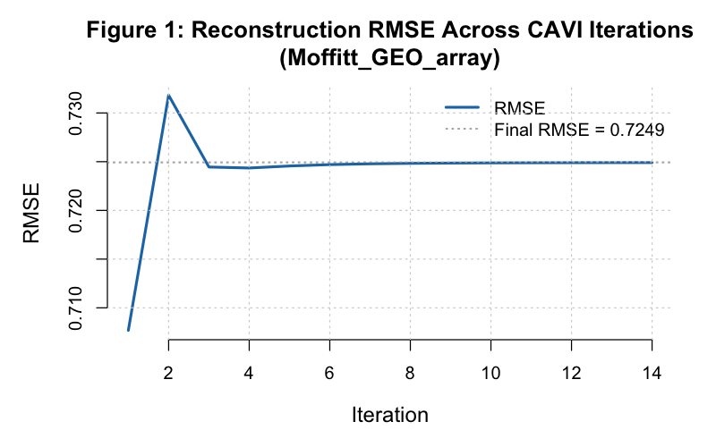

Moffitt GEO array RMSE trace

**Convergence history (first 5 and last 5 iterations):**

| Iteration | RMSE | ELBO Proxy |
| --- | --- | --- |
| 1 | 0.707691 | -36418.7 |
| 2 | 0.731821 | -20709.8 |
| 3 | 0.724453 | -19584.0 |
| 4 | 0.724352 | -19455.4 |
| 5 | 0.724559 | -19431.1 |
| NA | NA | NA |
| 10 | 0.724877 | -19424.8 |
| 11 | 0.724889 | -19425.0 |
| 12 | 0.724898 | -19425.3 |
| 13 | 0.724905 | -19425.5 |
| 14 | 0.724909 | -19425.6 |

**Figure 2 — ELBO Proxy Trace**

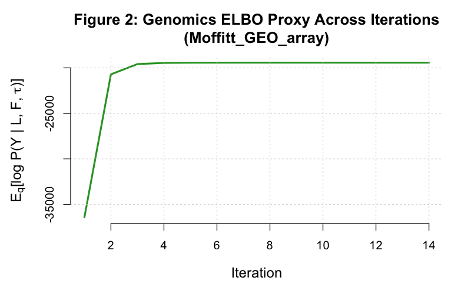

Moffitt GEO array ELBO trace

**Figure 3 — Survival Coefficient Estimates ($\hat\beta_k$)**

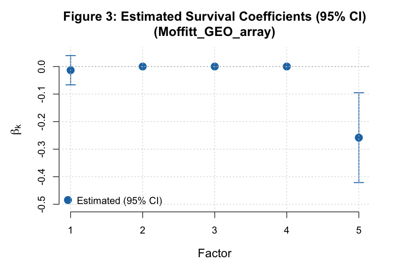

Moffitt GEO array beta estimates

*Prognostic factors: GEP 5 (protective, $\hat\beta$ = -0.258). Factors with $\hat\beta = 0$ were not retained by the EBNM shrinkage prior.*

**Factor Summary Table**

| Factor | β̂ | Log-rank p | Non-zero % | PVE % |
| --- | --- | --- | --- | --- |
| 1 | -0.013 | 0.7385 | 100 | 13.27 |
| 2 | 0.000 | 0.5479 | 100 | 9.90 |
| 3 | 0.000 | 0.8797 | 100 | 7.98 |
| 4 | 0.000 | 0.4828 | 100 | 3.87 |
| 5 | -0.258 | 0.0912 | 100 | 4.04 |

*All 1 factor(s) with non-zero $\hat\beta$ also show log-rank p < 0.1, confirming consistency between the parametric Cox estimate and the non-parametric survival test.*

**Figure 4 — GEP Heatmap (top 50 genes by total absolute weight)**

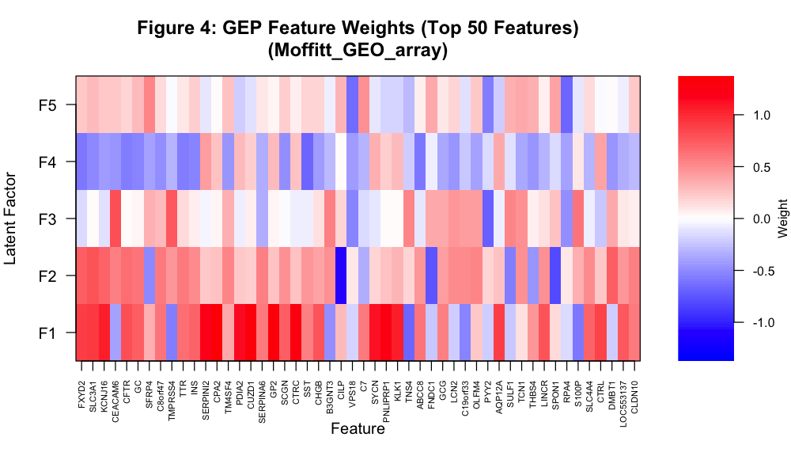

Moffitt GEO array GEP heatmap

*Factor 1 is the dominant expression component (PVE = 13.3%). It is not prognostically relevant ((β̂) ≈ 0), indicating the dominant expression axis does not drive survival here — the model separates expression variance from survival signal.*

**Figure 5 — Kaplan-Meier Survival Curves (High vs. Low loading)**

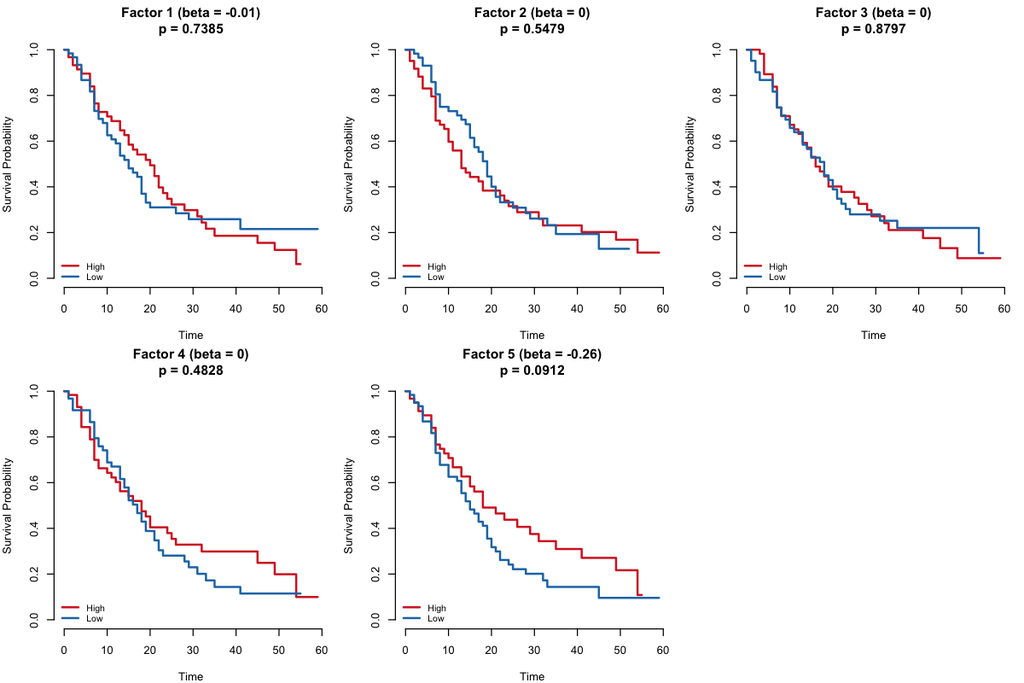

Moffitt GEO array Kaplan-Meier

*Significant stratification (log-rank p < 0.1): GEP 5 (p = 0.0912). Curve separation for these factors indicates the loading scores meaningfully partition patients by prognosis.*

**Proportional Hazards Test (Schoenfeld residuals)**

| Term | Chi-sq | DF | p-value |
| --- | --- | --- | --- |
| EL | 13.8458 | 5 | 0.0166 |
| GLOBAL | 13.8458 | 5 | 0.0166 |

*Global PH test p = 0.0166. Evidence of a PH violation — hazard ratios may change over follow-up time. Interpret Cox coefficients cautiously and consider time-stratified models.*

**C-index Comparison**

| Method | C-index |
| --- | --- |
| Top-5 PCA | 0.571 |
| Supervised Latent L | 0.593 |

*The supervised model outperforms PCA by +0.022 C-index points — survival-supervision extracts additional prognostic information beyond expression variance alone.*

**Figure 8 — Noise Precision Distribution ($\hat\tau_j$ across 5,000 genes)**

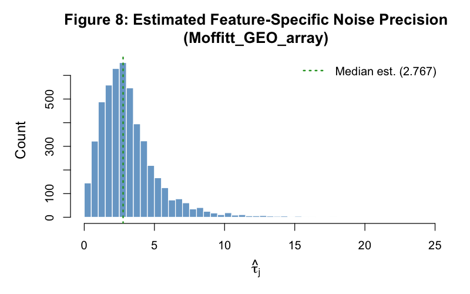

Moffitt GEO array tau distribution

*Microarray data tends to show a narrower tau distribution due to quantile or RMA normalisation, reflecting more uniform gene-level noise. The concentration of estimates near the median indicates the five-factor model accounts for a similar fraction of variance across most genes.*

**Top 10 Features per GEP**

*GEP 1 (non-prognostic)*

| Gene | Posterior Weight |
| --- | --- |
| CPA2 | 1.3596 |
| GP2 | 1.3147 |
| CUZD1 | 1.3117 |
| CPA1 | 1.2583 |
| CPB1 | 1.2561 |
| CTRC | 1.2520 |
| PNLIP | 1.2468 |
| PNLIPRP1 | 1.2413 |
| CTRB1 | 1.2309 |
| PRSS1 | 1.2160 |

*GEP 2 (non-prognostic)*

| Gene | Posterior Weight |
| --- | --- |
| CILP | -1.0798 |
| IGF1 | -0.8284 |
| SPON1 | -0.7896 |
| SLC3A1 | 0.7831 |
| FNDC1 | -0.7585 |
| CNN1 | -0.7086 |
| DMBT1 | 0.7084 |
| FXYD2 | 0.7078 |
| GREM1 | -0.6957 |
| MFAP5 | -0.6955 |

*GEP 3 (non-prognostic)*

| Gene | Posterior Weight |
| --- | --- |
| CEACAM6 | 0.8022 |
| TMPRSS4 | 0.7478 |
| CTSE | 0.7115 |
| PYY2 | -0.6945 |
| COL17A1 | 0.6855 |
| ANXA10 | 0.6757 |
| FA2H | 0.6611 |
| LAMC2 | 0.6545 |
| CEACAM5 | 0.6500 |
| LEMD1 | 0.6440 |

*GEP 4 (non-prognostic)*

| Gene | Posterior Weight |
| --- | --- |
| SST | -0.6550 |
| ABCC8 | -0.5976 |
| FXYD2 | -0.5817 |
| DUSP26 | -0.5783 |
| STMN2 | -0.5649 |
| CFTR | -0.5559 |
| TTR | -0.5439 |
| INS | -0.5380 |
| PIGR | -0.5379 |
| GC | -0.5235 |

*GEP 5 (β̂ = -0.258, protective)*

| Gene | Posterior Weight |
| --- | --- |
| ARGLU1 | -0.7595 |
| CABP7 | -0.6817 |
| PLEKHN1 | -0.6749 |
| RPA4 | -0.6603 |
| VPS18 | -0.6330 |
| LUC7L | -0.6289 |
| CGB1 | -0.6059 |
| C20orf96 | -0.5986 |
| LOC729602 | -0.5555 |
| FLJ40113 | -0.5538 |

**Note**

**Moffitt GEO array takeaway.** Converges in 14 iterations (RMSE: 0.7077 → 0.7249). Identifies 1/5 prognostic factors. C-index: supervised = 0.593 vs. PCA = 0.571 (+0.022). Global PH test p = 0.0166. PH assumption may be violated (global p < 0.05).

## 5.5 PACA AU array (Microarray, n=63)

**Convergence:** Yes at iteration 83 | **RMSE:** 0.9726 → 1.0165 | **Censoring:** 39.7%

**C-index:** PCA = 0.653 → Supervised = 0.623 (-0.030) | **Prognostic factors** (|β|>0.05, log-rank p<0.1): 0/5

**Figure 1 — RMSE Convergence Trace**

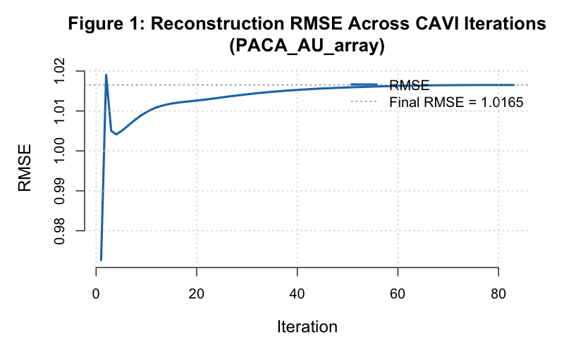

PACA AU array RMSE trace

**Convergence history (first 5 and last 5 iterations):**

| Iteration | RMSE | ELBO Proxy |
| --- | --- | --- |
| 1 | 0.972643 | -136024.3 |
| 2 | 1.019013 | -128077.8 |
| 3 | 1.005048 | -126959.1 |
| 4 | 1.004135 | -126727.4 |
| 5 | 1.004914 | -126625.2 |
| NA | NA | NA |
| 79 | 1.016503 | -126361.1 |
| 80 | 1.016505 | -126361.4 |
| 81 | 1.016506 | -126361.5 |
| 82 | 1.016507 | -126361.7 |
| 83 | 1.016507 | -126361.8 |

**Figure 2 — ELBO Proxy Trace**

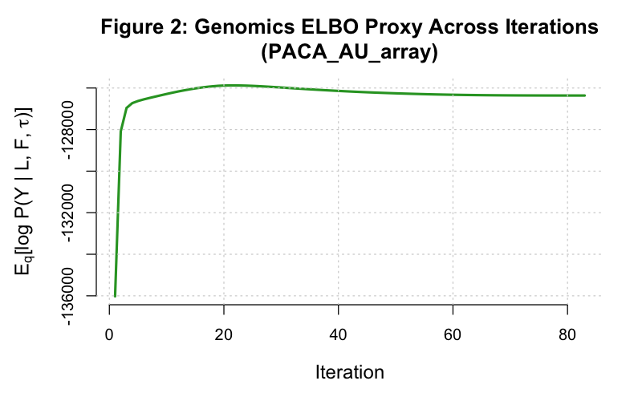

PACA AU array ELBO trace

**Figure 3 — Survival Coefficient Estimates ($\hat\beta_k$)**

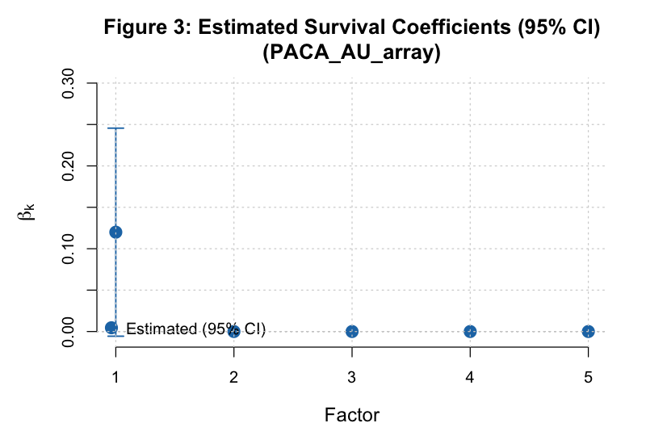

PACA AU array beta estimates

*Prognostic factors: GEP 1 (adverse, $\hat\beta$ = +0.120). Factors with $\hat\beta = 0$ were not retained by the EBNM shrinkage prior.*

**Factor Summary Table**

| Factor | β̂ | Log-rank p | Non-zero % | PVE % |
| --- | --- | --- | --- | --- |
| 1 | 0.12 | 0.2266 | 100 | 7.77 |
| 2 | 0.00 | 0.9171 | 100 | 6.88 |
| 3 | 0.00 | 0.8539 | 100 | 2.46 |
| 4 | 0.00 | 0.2008 | 100 | 2.68 |
| 5 | 0.00 | 0.0996 | 100 | 2.81 |

*0 of 1 factor(s) with non-zero $\hat\beta$ show log-rank p < 0.1; the discrepancy may reflect non-linear survival relationships that the median-split log-rank test captures but the linear Cox model does not.*

**Figure 4 — GEP Heatmap (top 50 genes by total absolute weight)**

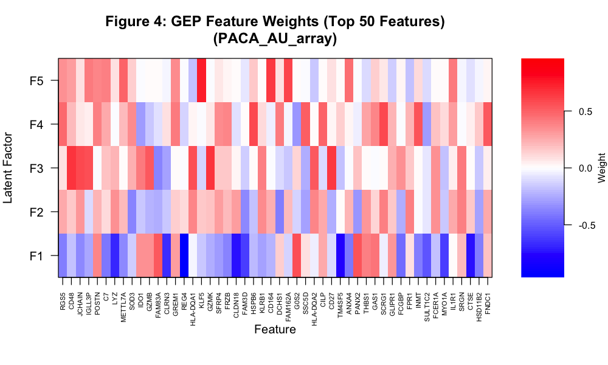

PACA AU array GEP heatmap

*Factor 1 is the dominant expression component (PVE = 7.8%). It is also prognostically relevant ((β̂) = +0.120), indicating the leading axis of expression variation is clinically meaningful in this cohort.*

**Figure 5 — Kaplan-Meier Survival Curves (High vs. Low loading)**

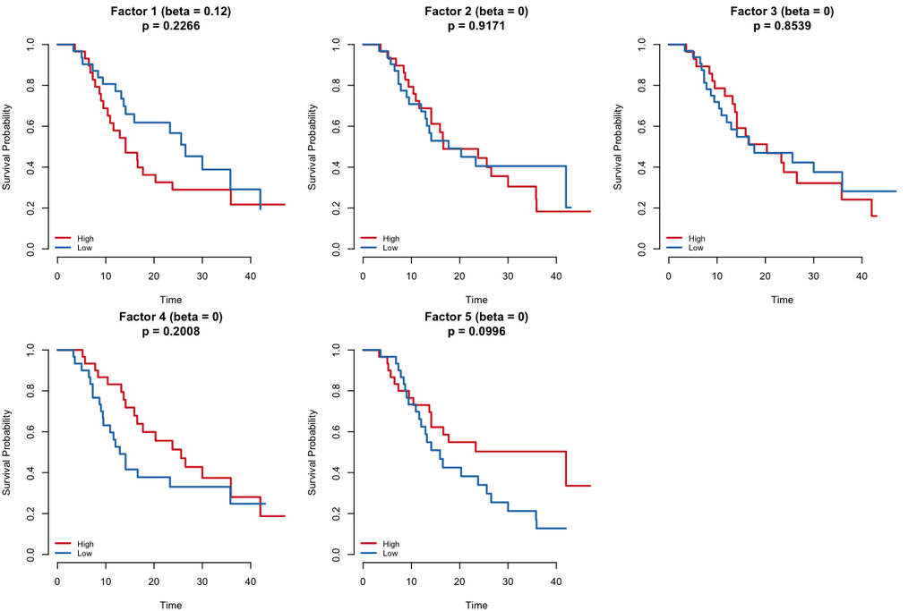

PACA AU array Kaplan-Meier

*Significant stratification (log-rank p < 0.1): GEP 5 (p = 0.0996). Curve separation for these factors indicates the loading scores meaningfully partition patients by prognosis.*

**Proportional Hazards Test (Schoenfeld residuals)**

| Term | Chi-sq | DF | p-value |
| --- | --- | --- | --- |
| EL | 6.3203 | 5 | 0.2763 |
| GLOBAL | 6.3203 | 5 | 0.2763 |

*Global PH test p = 0.2763. No evidence of a PH violation. The proportional hazards assumption is satisfied for the estimated factor loadings.*

**C-index Comparison**

| Method | C-index |
| --- | --- |
| Top-5 PCA | 0.653 |
| Supervised Latent L | 0.623 |

*PCA marginally outperforms the supervised model (-0.030). This can occur when survival signal is diffuse across many factors or when the point-normal prior is conservative relative to the cohort’s noise level.*

**Figure 8 — Noise Precision Distribution ($\hat\tau_j$ across 5,000 genes)**

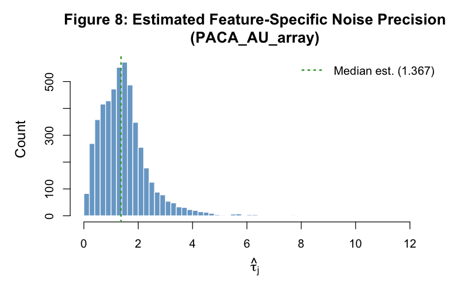

PACA AU array tau distribution

*Microarray data tends to show a narrower tau distribution due to quantile or RMA normalisation, reflecting more uniform gene-level noise. The concentration of estimates near the median indicates the five-factor model accounts for a similar fraction of variance across most genes.*

**Top 10 Features per GEP**

*GEP 1 (β̂ = +0.120, adverse)*

| Gene | Posterior Weight |
| --- | --- |
| REG4 | -0.9524 |
| TFF1 | -0.8707 |
| LGALS4 | -0.7853 |
| AKR1B10 | -0.7785 |
| TM4SF5 | -0.7619 |
| FMO5 | -0.7535 |
| CTSE | -0.7394 |
| CLDN18 | -0.7284 |
| HSD17B2 | -0.7186 |
| GPX2 | -0.7167 |

*GEP 2 (non-prognostic)*

| Gene | Posterior Weight |
| --- | --- |
| SNORA25 | -0.6320 |
| KIFC2 | -0.5857 |
| PRSS22 | -0.5695 |
| CPT1B | -0.5603 |
| PABPC1L | -0.5588 |
| NPIPA1 | -0.5585 |
| LRRC75B | -0.5415 |
| RAD9A | -0.5343 |
| SND1-IT1 | -0.5317 |
| ZNF692 | -0.5300 |

*GEP 3 (non-prognostic)*

| Gene | Posterior Weight |
| --- | --- |
| CD8A | 0.6921 |
| CXCL9 | 0.6626 |
| CD48 | 0.6622 |
| GZMK | 0.6586 |
| CD27 | 0.6444 |
| CD3D | 0.6344 |
| JCHAIN | 0.5762 |
| CD37 | 0.5667 |
| IGLL3P | 0.5659 |
| HLA-DQA1 | 0.5634 |

*GEP 4 (non-prognostic)*

| Gene | Posterior Weight |
| --- | --- |
| CNN1 | 0.7305 |
| MYH11 | 0.6834 |
| MYL9 | 0.6391 |
| TAGLN | 0.5999 |
| KCNMB1 | 0.5919 |
| PGM5 | 0.5900 |
| SCRG1 | 0.5897 |
| HSPB6 | 0.5829 |
| SFRP1 | 0.5806 |
| ACTG2 | 0.5504 |

*GEP 5 (non-prognostic)*

| Gene | Posterior Weight |
| --- | --- |
| KLF5 | 0.7244 |
| HECA | 0.6667 |
| ADI1 | 0.6562 |
| RAB33B | 0.6417 |
| CD164 | 0.6396 |
| NACAP1 | 0.6257 |
| ARHGAP18 | 0.6106 |
| UQCRFS1 | 0.6083 |
| FAM162A | 0.6044 |
| RPS4X | 0.6033 |

**Note**

**PACA AU array takeaway.** Converges in 83 iterations (RMSE: 0.9726 → 1.0165). Identifies 0/5 prognostic factors. C-index: supervised = 0.623 vs. PCA = 0.653 (-0.030). Global PH test p = 0.2763.